# Rによる機械学習 ロジスティック回帰

Cho（ztempest0218@gmail.com）

Last Updated: 2026-11-02

**データのダウンロード**

前回と同じKaggleの内向型・外向型データを使う。保存先は、講義のプロジェクトフォルダを基準にする。

- **演習データ**：train.csv ／ test.csvを `data/personality/` に保存する。

**今回の内容**

- 線形確率モデルとLogistic回帰
- Logistic関数・最大尤度法・Log Loss
- 閾値を使った分類と交差検証による閾値の選択
- Rによる内向型・外向型の分類とk-NNとの比較

# 1 OLS線形回帰からLogistic回帰へ

機械学習では、予測したい目的変数 $y$ によって、通常は次のようにタスクを呼び分ける。

| 予測したい $y$ | 例 | タスクの呼び方 |
| --- | --- | --- |
| **連続的な数値** | 売上金額・住宅価格 | **回帰（Regression）** |
| **カテゴリ・ラベル** | 購入する／しない | **分類（Classification）** |

ただし、機械学習は統計学や情報科学などが交わって発展した分野であり、**アルゴリズムの名前とタスクの呼び方は、必ずしも一致しない。**

- **線形回帰**  
  0・1の結果にも当てはめられ、分類にも使える。
- **二値Logistic回帰**  
  「回帰」という名前だが、この授業では分類タスクだけに使う。

アルゴリズム名にとらわれず、**予測したいものからタスクを考えよう**。前回のk-NNも、分類によく使われるが、連続的な数値 $y$ の予測にも使える。その場合は、近傍の $k$ 個のデータの $y$ を平均して予測値とする。

今回は、0・1の目的変数 $y$ にOLSを当てはめるところから始め、確率を非線形の曲線で表すLogistic回帰へと進む。

## 1.1 0・1の結果にOLSを当てはめる

年間所得 $x$ が200・400・600（万円）の3グループ（A・B・C、各100人）からなる架空の購入データを生成する。

```r
purchase <- data.frame(
  income = rep(c(200, 400, 600), each = 100),  # 単位：万円
  bought = c(
    rep(1, 20), rep(0, 80),  # A：100人
    rep(1, 50), rep(0, 50),  # B：100人
    rep(1, 80), rep(0, 20)   # C：100人
  )
)
```

購入の有無を次の $y$ で表す。1であれば購入したとし、0であれば購入しなかったとする。

$$y=\begin{cases}
1 & \text{if purchased} \\
0 & \text{otherwise}
\end{cases}$$

**線形確率モデル（Linear Probability Model）**では、0・1の $y_i$ に線形回帰を当てはめる。

$$y_i=\beta_0+\beta_1x_i+u_i,
\qquad y_i\in\{0,1\}$$

$i$ は個人、$x_i$ は所得、$u_i$ は誤差で、$\beta_0$ と $\beta_1$ がOLSで求める切片と傾きである。この300人の個人データにOLSを当てはめる。

```r
# OLSで直線を当てはめる
purchase_ols <- lm(bought ~ income, data = purchase)
coef(purchase_ols)
```

```
## (Intercept)      income
##     -0.1000      0.0015
```

所得の係数 $\hat{\beta}_1=0.0015$ は、年間所得が1万円高いと、予測される購入確率が0.15％ポイント高くなることを意味する。年間所得が100万円高いと、購入する確率が15％ポイント高くなる。線形確率モデルは、結果がとてもわかりやすい。

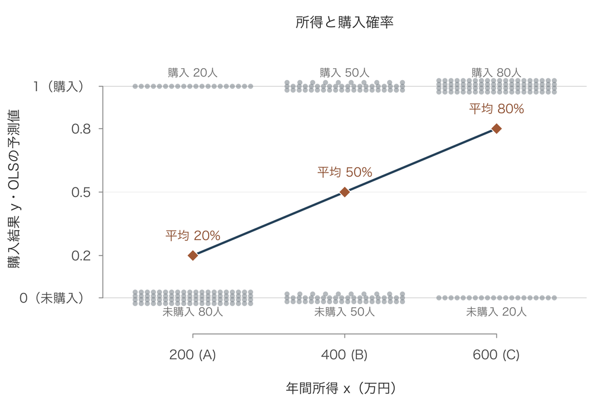

```r
# 散布図とOLSの直線
library(ggplot2)

ggplot(purchase, aes(income, bought)) +
  geom_jitter(width = 40, height = 0) +
  geom_smooth(method = "lm", se = FALSE) +
  theme_minimal()
```

※ 灰色の点は1人を表す。見やすくするために複数行に並べているが、実際の購入結果は0または1である。

線形確率モデルは、同じ所得 $x$ の人たちの購入結果 $y$ の平均（条件付き平均）を、直線で近似する。 ただし、各グループの平均点を必ず通るわけではない。

```r
aggregate(bought ~ income, data = purchase, FUN = mean)
```

表1：所得グループ別の購入割合

| グループ | 年間所得 | 購入した人数 / 全員 | 0・1の平均＝購入割合 |
| --- | --- | --- | --- |
| A | 200万円 | 20 / 100人 | 0.20（20%） |
| B | 400万円 | 50 / 100人 | 0.50（50%） |
| C | 600万円 | 80 / 100人 | 0.80（80%） |

0・1の $y$ では条件付き平均が購入確率に等しいため、線形確率モデルはこの確率を直線で近似する。

$$E[y\mid x]=P(y=1\mid x)$$

## 1.2 未知データでの予測

機械学習では、**学習に使っていないデータでの予測性能（**out-of-sample** performance）**を重視し、予測と実際の結果を比べて評価する。ここでは、先ほどの300人で学習した線形確率モデルを新しい人に使い、予測値を確認する。

$$\hat y=-0.10+0.0015x$$

| 年間所得 | 予測値 $\hat y$ | 確率の範囲 |
| --- | --- | --- |
| 500万円 | 0.65（65%） | 0〜1の範囲内 |
| 0万円 | −0.10（−10%） | **0未満** |
| 800万円 | 1.10（110%） | **1を超える** |

[figure not shown]

線形確率モデルには予測値を0〜1に収める仕組みがないため、**新しいデータで−10%や110%といった、確率として使えない値が出ることがある。** 機械学習では、0・1の二値分類にLogistic回帰が広く使われる。

補足：[Wooldridge（2009, §§7.5・17.1）](https://sfc33ed4d8ae30993.jimcontent.com/download/version/1422985041/module/5761805911/name/Introductory%20Econometrics%20A%20Modern%20Approach%20%20Edition%204.pdf)は、線形確率モデルをシンプルで有用なモデルと位置づけている。 線形確率モデルは、平均限界効果を重視する経済学で扱いやすい。平均的な効果に関心がある因果推論では、予測値が0〜1を外れる限界を踏まえても、線形モデルがよく使われる。

## 1.3 OLSとLogistic回帰の違い

機械学習では、一人ひとりの購入確率を予測する。所得が極端に低い人や高い人に線形確率モデルを使うと、予測値が0〜1を外れることがある。Logistic回帰は、関数変換によって予測値を0〜1に収める。 ここではまず違いを可視化し、数式や関数変換の詳しい仕組みは次章で説明する。

[figure not shown]

Logistic回帰では、購入確率と所得の関係が非線形で、曲線の傾きは所得によって変わる。そのため、係数を線形確率モデルのように確率の変化として直接読むことはできない。確率の変化を解釈するには、係数を**限界効果（marginal effect）**に換算する必要がある。

同じ300人のデータでLogitを推定し、先ほどのOLSと所得の係数を比較する。所得の単位は万円である。

**Logit：ロジスティック回帰**

```r
purchase_logit <- glm(bought ~ income, data = purchase, family = binomial)
summary(purchase_logit)
```

```
##
## Call:
## glm(formula = bought ~ income, family = binomial, data = purchase)
##
## Coefficients:
##               Estimate Std. Error z value Pr(>|z|)
## (Intercept) -2.7725887  0.3775497  -7.344 2.08e-13 ***
## income       0.0069315  0.0008839   7.842 4.43e-15 ***
## ---
## Signif. codes:  0 '***' 0.001 '**' 0.01 '*' 0.05 '.' 0.1 ' ' 1
##
## (Dispersion parameter for binomial family taken to be 1)
##
##     Null deviance: 415.89  on 299  degrees of freedom
## Residual deviance: 338.79  on 298  degrees of freedom
## AIC: 342.79
##
## Number of Fisher Scoring iterations: 4
```

Logitの所得係数は対数オッズ（後述）の変化を表す。確率の変化として比較するため、各人の予測確率 $p_i$ を使って限界効果 $\hat\beta_1 p_i(1-p_i)$ を求め、300人分を平均する。

```r
# 限界効果（Marginal Effect）に換算する
p <- predict(purchase_logit, type = "response")
marginal_effect <- coef(purchase_logit)["income"] * p * (1 - p)
mean(marginal_effect)
```

```
## [1] 0.00131698
```

|  | 推計値 |
| --- | --- |
| LPMの係数 | 0.00150 |
| Logitの係数 | 0.00693 |
| Logitの平均限界効果 | 約0.00132 |

OLSとLogitの係数は尺度が異なるため、直接比較してはいけない。

# 2 Logistic回帰

## 2.1 Logistic回帰の定式化

観測 $i$ の目的変数を $y_i\in\{0,1\}$、特徴量を $X_i=(x_{i1},\ldots,x_{id})$、$y_i=1$ となる確率を $p_i=P(y_i=1\mid X_i)$ とすると、Logistic回帰は次のように書ける。

$$\begin{gathered}
y_i\mid X_i\sim\operatorname{Bernoulli}(p_i),\\[6pt]
\operatorname{logit}(p_i)
=\underbrace{\ln\left(\frac{p_i}{1-p_i}\right)}_{\text{log odds}}
=
\beta_0+\beta_1x_{i1}+\cdots+\beta_dx_{id}
\end{gathered}$$

回帰式の右辺は線形回帰（OLS）と同じく、各変数に係数を掛けて足し合わせる形である。

一方、左辺は目的変数 $y_i$ そのものではなく、$X_i$ が与えられたときに $y_i=1$ となる条件付き確率 $p_i$ から計算した**対数オッズ（Logit）**である。

ここで、先ほどの購入する・しないの例に戻り、購入確率 $p$ とオッズを比べよう。確率は全員のうち、購入する人の割合、オッズは購入しない人に対して、購入する人が何倍いるかを表す。

$$\mathrm{odds}=\frac{p}{1-p}$$

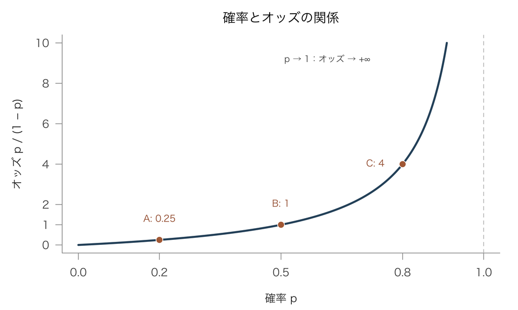

表1の各グループの購入割合をもとに、オッズとその自然対数であるLogitをそれぞれ計算すると、表2のようになる。

表2：所得グループ別の購入確率・オッズ・Logit

| グループ | 購入確率 $p$ | 未購入確率 $1-p$ | オッズ $p/(1-p)$ | Logit |
| --- | --- | --- | --- | --- |
| A：200万円 | 0.20 | 0.80 | 0.25 | −1.386 |
| B：400万円 | 0.50 | 0.50 | 1.00 | 0 |
| C：600万円 | 0.80 | 0.20 | 4.00 | 1.386 |

$0<p<1$ のとき、オッズは正の値を取り、Logitは負の値も正の値も取る。変換するのは確率 $p$ であり、個人の0・1の結果 $y$ ではない。確率 $p$ が0から1に近づくにつれて、Logitは負の値から正の値へ変化し、その範囲は $-\infty$ から $+\infty$ まで広がる。

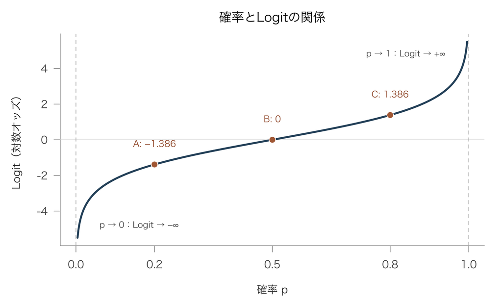

例えば、Cでは100人のうち80人が購入し、20人が購入しなかった。購入する人は購入しない人の4倍なので、オッズは4である。一方、Aでは購入する人20人に対して購入しない人が80人いるため、オッズは $20/80=0.25$ である。Bでは購入する人としない人が同じ50人なので、オッズは1になる。

Logistic回帰では、条件付き確率を変換した**Logitスコア**を特徴量の線形結合で表す。係数は、他の特徴量を一定としたときのLogitスコアの変化を表し、確率の変化として直接解釈することはできない。

## 2.2 Logistic関数で確率に戻す

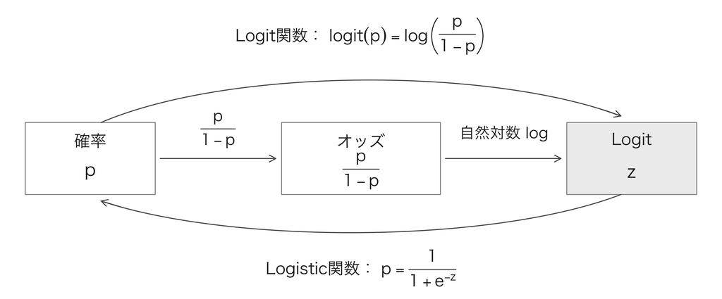

Logistic回帰の係数は、他の特徴量を一定としたとき、$x$ が1単位増えた場合のLogitスコアの変化を表す。係数は確率の限界効果（marginal effect）ではない。

よって、予測するときは、逆にLogitスコアから確率へ戻す。線形の部分を $z=\beta_0+\beta_1x_1+\cdots+\beta_dx_d$ と置くと、

$$\log\left(\frac{p}{1-p}\right)=z
\quad\Longrightarrow\quad
\frac{p}{1-p}=e^z
\quad\Longrightarrow\quad
p=\frac{e^z}{1+e^z}=\frac{1}{1+e^{-z}}$$

$\operatorname{logit}(p)$ は確率 $p$ をLogitスコア $z$ に変換する**Logit関数（Logit function）**である。一方、$\sigma(z)$ はLogitスコアを確率に戻す**シグモイド関数（Sigmoid function）**であり、Logistic sigmoid関数やLogistic関数とも呼ばれる（sigmoidは広い意味ではS字形の関数を指すが、機械学習では通常Logistic sigmoid関数を指す）。この2つは互いに逆関数であり、確率とLogitスコアの間を変換できる。

$$z=\operatorname{logit}(p)
\qquad\Longleftrightarrow\qquad
p=\sigma(z)=\frac{1}{1+e^{-z}}$$

ここで、$z$ は説明変数の重み付きの和で、標準化したzスコアではない。有限の $z$ を入れると、必ず $0<p<1$ になる。

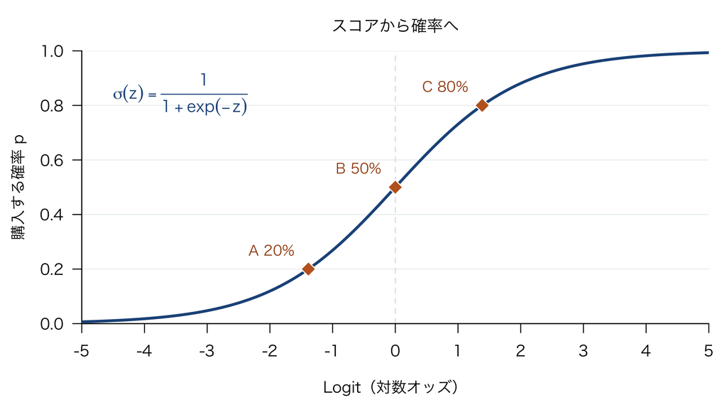

第1章で推定したLogistic回帰を使い、学習データにはない所得300・500・700万円の購入確率を予測する。`predict()` は、`type = "link"` でLogitスコアを、`type = "response"` で確率を返す。

```r
# 学習データにない所得の購入確率を予測
new_data <- data.frame(income = c(300, 500, 700))

# Logitスコア
predict(purchase_logit, newdata = new_data, type = "link")
```

```
##          1          2          3
## -0.6931472  0.6931472  2.0794415
```

```r
# 購入確率
predict(purchase_logit, newdata = new_data, type = "response")
```

```
##         1         2         3
## 0.3333333 0.6666667 0.8888889
```

予測される購入確率は、それぞれ約33%・67%・89%である。 検証データやテストデータを予測するときも、`newdata` に対象のデータを指定すればよい。予測に必要な特徴量は、学習時と同じ名前・形式で用意する。

## 2.3 最大尤度法とLog Loss

線形回帰では、実際の値と予測値の二乗誤差を小さくして係数を決めた。Logistic回帰では、0・1の結果に対する確率モデルに基づき、通常は**最大尤度法（Maximum Likelihood）**で係数を決める。

**尤度（likelihood）**は、観測されたデータを固定し、候補となるパラメータのもとで、そのデータがどの程度得られやすいかを表す値である。離散データでは確率、連続データでは確率密度に基づいて計算する。Logistic回帰では、目的変数が0・1なので、各人に実際に観測された結果の確率を使って尤度を計算する。

例えば、2人のうち1人目は購入し、2人目は購入しなかったとする。2人の購入確率が同じ $p$ で、それぞれの結果が独立だとすると、この結果に対応する尤度は $p(1-p)$ である。

表3：購入確率の候補と尤度

| 候補の購入確率 | 1人目が購入 | 2人目が未購入 | 尤度（2つの結果の確率の積） |
| --- | --- | --- | --- |
| $p=0.8$ | 0.8 | 0.2 | $0.8\times0.2=0.16$ |
| $p=0.5$ | 0.5 | 0.5 | $0.5\times0.5=0.25$ |

実際の結果は同じでも、$p=0.5$ の方がその結果に高い確率を与える。**最大尤度法**は、この尤度が最大になるようにモデルのパラメータを選ぶ方法である。ただし、購入・未購入は偶然かもしれず、一度の結果だけでは本当の購入確率は分からない。

Logistic回帰で学習するのは、回帰式の係数 $\beta=(\beta_0,\beta_1,\ldots,\beta_d)$ である。係数を変えると、各人の特徴量 $X_i$ から計算される確率 $p_i=\sigma(\beta_0+\beta_1x_{i1}+\cdots+\beta_dx_{id})$ も変わる。観測された各人の結果の確率を掛け合わせ、**尤度が最大になる係数** $\beta$ を探す。特徴量を条件として各人の結果が独立だとすると、全体の尤度は次のようになる。

$$L(\beta)=\prod_{i=1}^{n}p_i^{y_i}(1-p_i)^{1-y_i}\tag{1}$$

式(1)では0から1の間の確率を何度も掛けるため、積が非常に小さくなり、数値精度の問題が生じやすい。そこで、通常は尤度の対数を取り、掛け算を足し算に変える。対数は単調に増えるので、最大になる係数は変わらない。

$$\ell(\beta)=\log L(\beta)
=\sum_{i=1}^{n}\left[y_i\log p_i+(1-y_i)\log(1-p_i)\right]\tag{2}$$

統計学や計量経済学では、式(2)の対数尤度を最大化する形で表すことが多い。一方、機械学習では、RMSEなどと同じく**値が小さいほどよい損失**として表すことが多い。また、対数尤度の合計はサンプル数の影響を受けるため、人数 $n$ で割ることで1人あたりの平均損失になる。

式(2)の符号を反転し、サンプル数で割ったものが、**Log Loss**である。二値交差エントロピー（Binary Cross-Entropy、BCE）とも呼ばれる。

$$\operatorname{LogLoss}(\beta)
=-\frac{\ell(\beta)}{n}
=-\frac{1}{n}\sum_{i=1}^{n}\left[y_i\log
p_i+(1-y_i)\log(1-p_i)\right]\tag{3}$$

同じデータとモデルで正則化を加えない場合、尤度を最大化して得られる係数 $\beta$ と、Log Lossを最小化して得られる係数 $\beta$ は一致する。 機械学習では、損失を小さくする形のLog Lossがよく使われる。

実際の結果が購入（$y=1$）か未購入（$y=0$）かによって、1人分のLog Lossは次のように変わる。

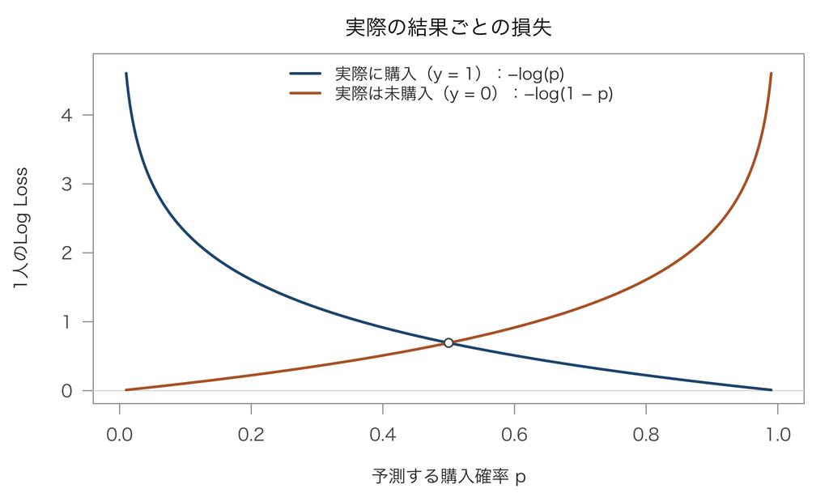

例えば、実際に購入した人に購入確率90%を予測すれば損失は小さい。一方、購入確率10%を予測すると、実際の結果に低い確率を与えたため損失は大きい。未購入の場合は逆になる。自信を持って間違えた予測ほど、Log Lossは大きくなる。

前の購入データと推定済みモデルを使い、実際の結果と予測確率からLog Lossを計算する。

```r
# 各人の予測確率と実際の購入結果
p <- predict(purchase_logit, type = "response")
y <- purchase$bought

# 1人ずつの損失を計算し、全員で平均する
log_loss <- -mean(y * log(p) + (1 - y) * log(1 - p))
log_loss
```

```
## [1] 0.5646507
```

`logLik()` で推定済みモデルの対数尤度（式(2)）を取得し、符号を反転してサンプル数で割っても同じ値を得られる。

```r
# 学習データの対数尤度から平均Log Lossを求める
-as.numeric(logLik(purchase_logit)) / nobs(purchase_logit)
```

```
## [1] 0.5646507
```

このデータの平均Log Lossは約0.565である。これは学習データでの結果である。未知データに対する予測性能は、検証データとテストデータで評価する。

## 2.4 確率から分類へ

Logistic回帰が出力するのは、目的変数が1となる**確率**であり、0.1や0.2のように0から1の間の値をとる。一方、実際に観測される $y$ は、行動をとったか、薬を飲んだか、商品を購入したかのように、通常は0または1である。

事象が起こるかどうかを0または1で予測したい場合、予測確率を区切る**閾値（threshold）** $t$ を指定する。

$$\hat{y}_i = \begin{cases}
1 & (\hat{p}_i \geq t) \\
0 & (\hat{p}_i < t)
\end{cases}$$

統計学や計量経済学では、分類する際に $t=0.5$ を標準的な基準として用いることが多い。予測確率が0.5以上なら1（購入）、0.5未満なら0（未購入）と予測する。

閾値は必ずしも0.5である必要はなく、0.5が最もよい分類結果を与えるとは限らない。適切な閾値はデータの分布や評価指標、誤分類の代償によって異なる。そのため、**閾値をハイパーパラメータとして、交差検証で選ぶ**こともできる。

|  |  | 予測 無罪 | 予測 有罪 |
| --- | --- | --- | --- |
| 実際 | 無罪 | 正しい判断 | 第一種の誤り **冤罪** |
|  | 有罪 | 第二種の誤り 証拠不足 | 正しい判断 |

予測の誤りの重大さは、利用する場面によって異なる。例えば犯罪の有無を判断する場面では、無罪の人を有罪とする**冤罪**（第一種の誤り）は特に深刻である。一方、がんの検査では、がんがある人を「がんなし」と見逃す**偽陰性**（第二種の誤り）が、診断や治療の遅れにつながるため、特に重視される場合がある。したがって、閾値を選ぶ際には、それぞれの誤りの影響を考える必要がある。

# 3 Rによる内向型・外向型の分類

前回のk-NNと同じ personalityデータを使い、7つの特徴量から内向型・外向型を予測する。Logistic回帰で外向型の確率を求め、確率と分類の両方を評価する。

## 3.1 データと前処理

前回と同じく、正解ラベルのある `train.csv` を交差検証で学習部分と検証部分に分ける。Kaggleの `test.csv` は正解ラベルのないテストデータであり、ここでは評価に使わない。

```r
library(tidyverse)
library(recipes)
library(caret)
library(ModelMetrics)

# 適宜wdを設定すること

personality <- read.csv("data/personality/train.csv", na.strings = "")
personality$Personality <- factor(personality$Personality,
                                  levels = c("Introvert", "Extrovert"))
kaggle_test <- read.csv("data/personality/test.csv", na.strings = "")
```

結果変数 `Personality` は因子型にし、水準の順序を明示している。二値のLogistic回帰では、最初の水準 `Introvert` が基準の0、二番目の水準 `Extrovert` が1に対応し、外向型となる確率を予測する。`levels(personality$Personality)` で順序を確認できる。

$$y_i = \begin{cases}
1 & \text{Extrovert} \\
0 & \text{Introvert}
\end{cases}$$

識別番号 `id` は使わない。数値の欠損値は中央値、カテゴリの欠損値は最頻値で補完し、カテゴリ変数は因子として扱い、モデルの推定時に必要な変数へ変換される。通常のLogistic回帰では標準化は必須ではないため、ここでは行わない。`recipe` は処理の手順を定義するだけで、補完値は交差検証の学習部分から求める。

```r
# yを指定し、idを除く
rec <- recipe(Personality ~ ., data = select(personality, -id)) %>%
  # 数値の欠損値：中央値で補完
  step_impute_median(all_numeric_predictors()) %>%
  # カテゴリの欠損値：最頻値で補完
  step_impute_mode(all_nominal_predictors()) %>%
  # 変動しない変数を除く
  step_zv(all_predictors())
```

**前回のk-NNの前処理と比べてみよう**。Rの回帰分析では、カテゴリ変数を因子型として指定すると、モデルが必要なダミー変数を自動的に作るため、手動で作成する必要はない。因子を使った場合と、自分でダミー変数を作った場合で、同じ推定結果が得られるか試してみよう。比較するときは、基準カテゴリと切片の扱いをそろえる必要がある。

## 3.2 交差検証用のデータとfoldを準備する

学習データを5つのfoldに分ける。各回は4つを学習、残り1つを検証に使い、役割を入れ替える。

今回は、クラスの予測だけでなく予測確率も使うため、`trainControl()` に次の設定を追加する。

- `classProbs = TRUE`：各クラスの予測確率を計算する。後でLog Lossの計算と閾値の選択に使う。

Logistic回帰の閾値 $t$ は係数の推定には使わず、予測確率を0・1に分ける基準である。今回は `"final"` で各foldの予測確率を保存し、同じ確率に異なる閾値を適用して比較する。**$t$ を変えるたびにモデルを学習し直す必要はない**ため、閾値ごとに分類結果と評価指標を計算するだけでよい。

```r
# trainは、foldに分割する前のtrain.csv全体を表す
train <- personality

# 5分割の交差検証サンプルを用意する
set.seed(2026)
folds <- createFolds(train$Personality, k = 5, returnTrain = TRUE)
control <- trainControl(method = "cv", number = 5, index = folds,
                        classProbs = TRUE, savePredictions = "final")
```

## 3.3 Logistic回帰の学習と閾値の選択

Logistic回帰は `glm()` と `glmnet()` のどちらでも推定できる。`glmnet` ではRidgeやLassoによる正則化も可能であり、Lassoは変数選択にも使える。

今回は正則化を加えず、単純な `glm()` を用いる。`caret::train()` で `method = "glm"` と `family = binomial()` を指定し、前処理 `rec` と交差検証の設定 `control` を使って学習する。

```r
# 再現できるよう乱数シードを設定
set.seed(123)

# 前処理と5分割交差検証を使ってLogistic回帰を学習
logit_fit <- train(
  rec,                 # 前処理の手順
  data = train,        # 学習データ
  method = "glm",      # 一般化線形モデル
  family = binomial(), # 二値のLogistic回帰
  trControl = control  # 交差検証の設定
)
```

交差検証の各予測は、その観測を含まない学習部分から得たものである。`caret` が保存する `Extrovert` 列は外向型の予測確率を表す。

### 3.3.1 予測確率をLog Lossで評価する

予測確率は、閾値を使わずにLog Lossで評価できる。`logLoss()` は `ModelMetrics` パッケージの関数であり、あらかじめ `library(ModelMetrics)` で読み込む。`actual` に実際の0・1、`predicted` に1となる予測確率を指定する。ここでは外向型を1として計算する。2.3節のように、式を使って手動で計算することもできる。

```r
# 交差検証の検証データに対する予測結果を取り出す
cv_pred <- logit_fit$pred

# 外向型となる予測確率を取り出す
prob_extrovert <- cv_pred$Extrovert

# 実際の結果と予測確率からLog Lossを計算
cv_log_loss <- logLoss(
  actual = cv_pred$obs == "Extrovert", # 実際に外向型ならTRUE（1）
  predicted = prob_extrovert           # 外向型の予測確率
)
cv_log_loss
```

```
## [1] 0.146643
```

これは5回の検証予測をまとめて計算したLog Lossである。予測確率を重視する場合、異なるモデルや変数の組み合わせを交差検証のLog Lossで比較し、小さいものを選ぶこともできる。手順はRidge・Lassoの章でRMSEを使って比較した例を参照しよう。今回は比較を省略し、次に閾値を選ぶ。

### 3.3.2 交差検証で閾値 $t$ を選ぶ

`caret::thresholder()` で閾値 $t$ を0.05から0.95まで0.01刻みで比較し、交差検証の平均正解率が最も高い値を選ぶ。評価指標は目的に応じて変更できる。

Rでは、因子水準の扱いがパッケージや関数によって異なる場合がある。`glm()` は二値の因子の第2水準を1として扱う一方、`thresholder()` は第1水準の確率を対象にする。そのため、評価用のコピーで外向型を先頭にする。`thresholder()` は確率が閾値を上回る場合に外向型とする。2.4節の例では閾値と等しい場合も1としたが、ここではこの関数の基準に合わせる。

```r
# 閾値の評価用にコピーし、外向型を最初の水準にする
threshold_fit <- logit_fit
threshold_fit$levels <- c("Extrovert", "Introvert")
threshold_fit$pred$obs <- relevel(threshold_fit$pred$obs, ref = "Extrovert")

# 交差検証の予測確率を使い、各閾値の平均正解率を計算
thresholds <- seq(0.05, 0.95, by = 0.01)
threshold_results <- thresholder(threshold_fit, threshold = thresholds,
                                statistics = "Accuracy")

# 同じ正解率なら0.5に近い候補を選ぶ
threshold_results <- threshold_results %>%
  arrange(desc(Accuracy), abs(prob_threshold - 0.5), prob_threshold)
best_t <- threshold_results$prob_threshold[1]
head(threshold_results)
```

|  | parameter | prob_threshold | Accuracy |
| --- | --- | --- | --- |
| 1 | none | 0.77 | 0.9690130 |
| 2 | none | 0.78 | 0.9690130 |
| 3 | none | 0.76 | 0.9689050 |
| 4 | none | 0.79 | 0.9689050 |
| 5 | none | 0.66 | 0.9688511 |
| 6 | none | 0.67 | 0.9688511 |

```r
best_t
```

```
## [1] 0.77
```

閾値を動かしても、学習済みモデルの係数や予測確率、Log Lossは変わらない。変わるのは確率を0・1に分類する基準である。

## 3.4 交差検証の予測結果を確認する

選んだ閾値 $t$ を交差検証の予測に適用する。外向型の予測確率が $t$ を上回れば外向型、$t$ 以下なら内向型と分類し、混同行列、正解率、各クラスの再現率を確認する。

```r
# 選んだ閾値を使って予測確率を分類する
cv_class <- factor(
  ifelse(prob_extrovert > best_t, "Extrovert", "Introvert"),
  levels = c("Introvert", "Extrovert")
)
confusion <- table(Actual = cv_pred$obs, Predicted = cv_class)
confusion
```

```
##            Predicted
## Actual      Introvert Extrovert
##   Introvert      4524       301
##   Extrovert       273     13426
```

```r
# 混同行列から正解率を計算
sum(diag(confusion)) / sum(confusion)
```

```
## [1] 0.9690132
```

```r
# 混同行列confusionを使って再現率を計算
data.frame(
  class = rownames(confusion),
  recall = diag(confusion) / rowSums(confusion)
) %>% knitr::kable(digits = 3, row.names = FALSE)
```

| class | recall |
| --- | --- |
| Introvert | 0.938 |
| Extrovert | 0.980 |

次の節で、前回のk-NNの結果と比較する。

## 3.5 k-NNとの比較

前回の最頻値による基準モデルとk-NN（$k=31$）の結果、今回のLogistic回帰（$t=0.77$）を比較する。いずれも同じ `data/personality/train.csv` と5分割の交差検証を用いている。

| Model | Accuracy | Recall_Introvert | Recall_Extrovert |
| --- | --- | --- | --- |
| Majority | 0.7395 | 0.0000 | 1.0000 |
| k-NN (k = 31) | 0.9687 | 0.9349 | 0.9807 |
| Logistic (t = 0.77) | 0.9690 | 0.9376 | 0.9801 |

同じデータと分割方法を使い、同じ乱数シードを設定しているため、両モデルは同じ交差検証のfoldを使っている。ただし、検証データをハイパーパラメータの選択と性能の比較の両方に使っているため、結果はやや楽観的になりうる。 テストデータにおける性能は、各自、予測結果をKaggleにアップロードして確かめてください。

この結果は、Logistic回帰がk-NNより常に優れていることを意味しない。データによって結果は異なりうるため、今回の比較は一つの参考として捉えよう。

# 4 まとめ

Logistic回帰は0・1の結果を確率として予測し、閾値を使って分類する。線形確率モデル（LPM）は係数を確率の変化として直接解釈できる一方、予測値が0～1の範囲外になることがある。

ProbitとLogitはそれぞれ標準正規分布とロジスティック分布の累積分布関数を使い、予測は似ることが多い。**機械学習ではLogitが広く使われ、大規模データでは計算式の単純さが利点**になりうる。ただし、実際の計算時間は実装などによって異なり、Logitの予測性能が常に高いわけではない。

どのモデルも常に優れているとは限らない。LPMは解釈しやすく因果推論でも使われるが、因果解釈には適切な研究デザインと仮定が必要である。目的やデータに応じてモデルを選ぼう。